# UnsupervisedLearning

bhaskar

## PRINCIPAL COMPONENT ANALYSIS a.k.a PCA

Low dimensional representation of the feature space that contains as much as possible of the variation.

The n observations lives in p dimensionsions, but not all the dimensions are equally interesting, PCA seeks small number of dimensions that are as interesting as possible (Interseting = amount that observations vary along each dimension).

each principal component is a linear combination of feature space, loading vector of first PCA defines direction in which data varies most.

Of all the possible linear combination of features that are uncorrelated with first PCA , the one in which data varies the most is second PCA.

Results of PCA change if measurement unit of a single predictor is adjusted, hence using default of centering and scaling and deviating only when all the predictors are measured on the same scale makes useful principal components.

**Principal components on *USArrests* data**

```r
library(dplyr)
names(USArrests)
```

```
## [1] "Murder"   "Assault"  "UrbanPop" "Rape"
```

```r
USArrest = tbl_df(USArrests)
glimpse(USArrest)
```

```
## Observations: 50
## Variables: 4
## $ Murder   <dbl> 13.2, 10.0, 8.1, 8.8, 9.0, 7.9, 3.3, 5.9, 15.4, 17.4,...
## $ Assault  <int> 236, 263, 294, 190, 276, 204, 110, 238, 335, 211, 46,...
## $ UrbanPop <int> 58, 48, 80, 50, 91, 78, 77, 72, 80, 60, 83, 54, 83, 6...
## $ Rape     <dbl> 21.2, 44.5, 31.0, 19.5, 40.6, 38.7, 11.1, 15.8, 31.9,...
```

```r
USArrest %>% rownames()
```

```
##  [1] "Alabama"        "Alaska"         "Arizona"        "Arkansas"
##  [5] "California"     "Colorado"       "Connecticut"    "Delaware"
##  [9] "Florida"        "Georgia"        "Hawaii"         "Idaho"
## [13] "Illinois"       "Indiana"        "Iowa"           "Kansas"
## [17] "Kentucky"       "Louisiana"      "Maine"          "Maryland"
## [21] "Massachusetts"  "Michigan"       "Minnesota"      "Mississippi"
## [25] "Missouri"       "Montana"        "Nebraska"       "Nevada"
## [29] "New Hampshire"  "New Jersey"     "New Mexico"     "New York"
## [33] "North Carolina" "North Dakota"   "Ohio"           "Oklahoma"
## [37] "Oregon"         "Pennsylvania"   "Rhode Island"   "South Carolina"
## [41] "South Dakota"   "Tennessee"      "Texas"          "Utah"
## [45] "Vermont"        "Virginia"       "Washington"     "West Virginia"
## [49] "Wisconsin"      "Wyoming"
```

```r
USArrest %>% summarise_each(funs(mean))
```

```
## # A tibble: 1 × 4
##   Murder Assault UrbanPop   Rape
##    <dbl>   <dbl>    <dbl>  <dbl>
## 1  7.788  170.76    65.54 21.232
```

```r
USArrest %>% summarise_each(funs(var))
```

```
## # A tibble: 1 × 4
##     Murder  Assault UrbanPop     Rape
##      <dbl>    <dbl>    <dbl>    <dbl>
## 1 18.97047 6945.166 209.5188 87.72916
```

As variances are different Principal components will be dominated by Highest varying column variance

```r
pr.out.unscaled = prcomp(USArrest)
pr.out.unscaled$center
```

```
##   Murder  Assault UrbanPop     Rape
##    7.788  170.760   65.540   21.232
```

```r
pr.out.unscaled$scale
```

```
## [1] FALSE
```

```r
pr.out.unscaled$rotation
```

```
##                 PC1         PC2         PC3         PC4
## Murder   0.04170432 -0.04482166  0.07989066 -0.99492173
## Assault  0.99522128 -0.05876003 -0.06756974  0.03893830
## UrbanPop 0.04633575  0.97685748 -0.20054629 -0.05816914
## Rape     0.07515550  0.20071807  0.97408059  0.07232502
```

```r
pr.out.unscaled$x %>% dim()
```

```
## [1] 50  4
```

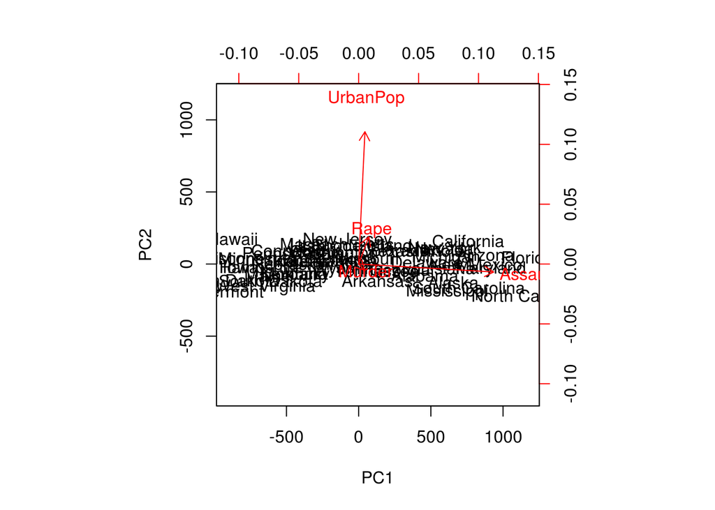

```r
biplot(pr.out.unscaled,scale = 0,pc.biplot = T)
```

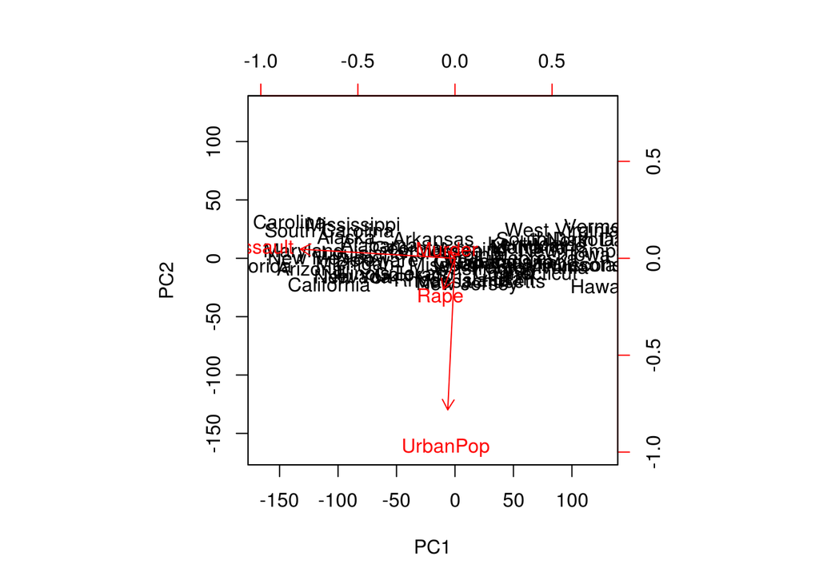

```r
# multipl
pr.out.unscaled$rotation = - pr.out.unscaled$rotation
pr.out.unscaled$x = - pr.out.unscaled$x
biplot(pr.out.unscaled,scale = 0)
```

column *‘x’* in the output is the scores, *‘rotation’* is the loadings, *‘scale = 0’* in biplot makes the length of arrow equal to loadings.

```r
pr.out = prcomp(USArrest,scale. = T)
pr.out$center
```

```
##   Murder  Assault UrbanPop     Rape
##    7.788  170.760   65.540   21.232
```

```r
pr.out$scale
```

```
##    Murder   Assault  UrbanPop      Rape
##  4.355510 83.337661 14.474763  9.366385
```

```r
pr.out$rotation
```

```
##                 PC1        PC2        PC3         PC4
## Murder   -0.5358995  0.4181809 -0.3412327  0.64922780
## Assault  -0.5831836  0.1879856 -0.2681484 -0.74340748
## UrbanPop -0.2781909 -0.8728062 -0.3780158  0.13387773
## Rape     -0.5434321 -0.1673186  0.8177779  0.08902432
```

```r
pr.out$x %>% dim()
```

```
## [1] 50  4
```

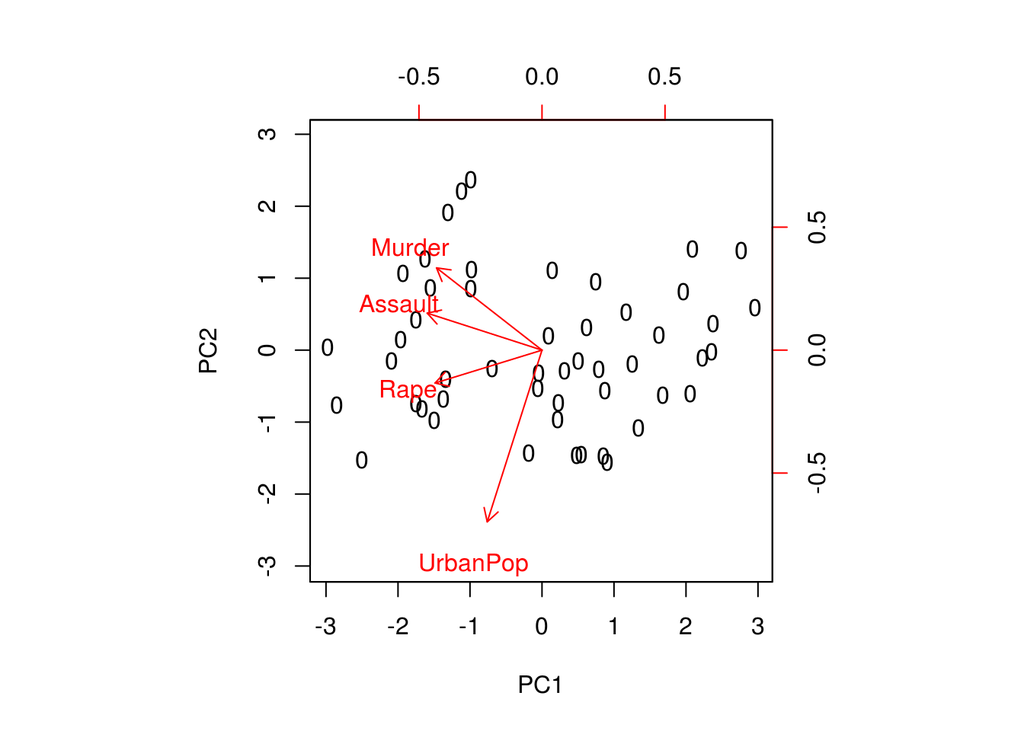

```r
biplot(pr.out,scale = 0,xlabs=rep("0",nrow(USArrest)))
```

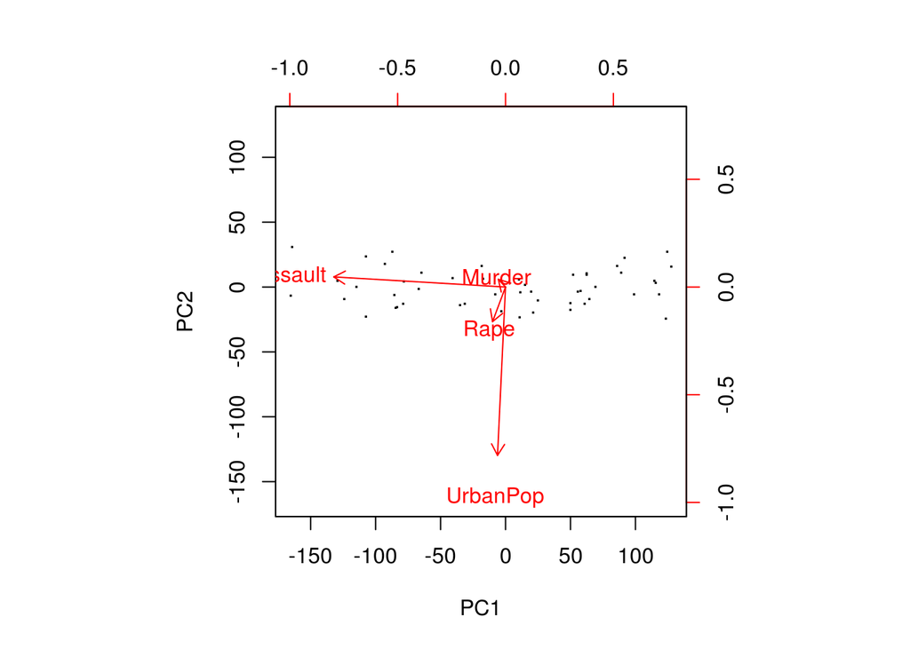

```r
biplot(pr.out.unscaled,scale = 0,xlabs=rep(".",nrow(USArrest)))
```

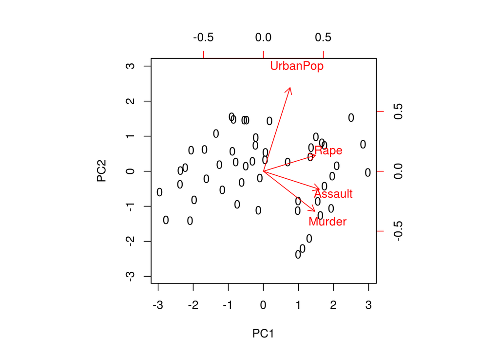

```r
pr.out$rotation = - pr.out$rotation
pr.out$x = - pr.out$x
biplot(pr.out,scale = 0,xlabs=rep("0",nrow(USArrest)))
```

```r
pr.out$sdev
```

```
## [1] 1.5748783 0.9948694 0.5971291 0.4164494
```

```r
pr.var = pr.out$sdev^2
pr.var
```

```
## [1] 2.4802416 0.9897652 0.3565632 0.1734301
```

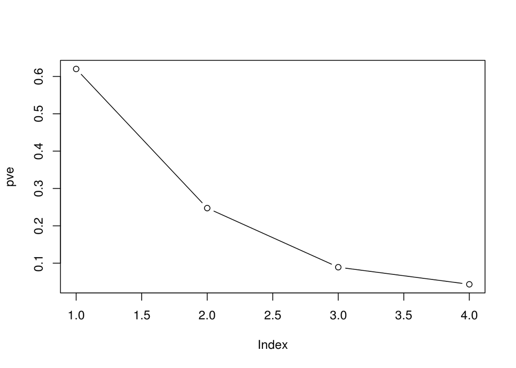

```r
pve = pr.var/sum(pr.var)
plot(pve,type = "b")
```

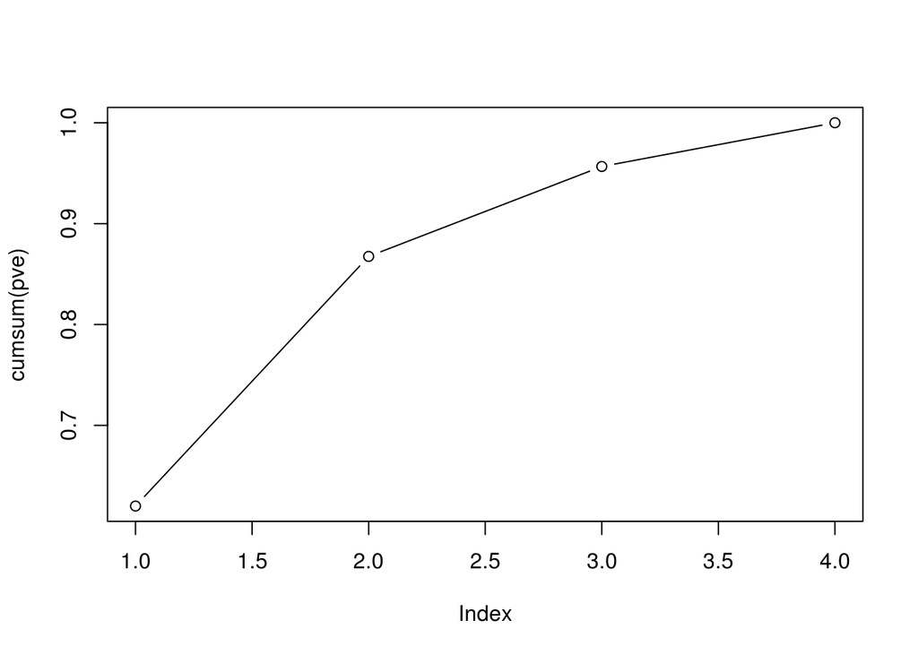

```r
plot(cumsum(pve),type = "b")
```

## CLUSTERING METHODS

Techniques to find subgroups or clusters in data.

To perform clustering we need to define what it means for two or more observations to be **similar** or **different**. This is often defined using *domain specific considerations* or based on the knowledge of *data* being studied.

We can find clusters in observations based on features or vice versa.

### K-Means clustering

classifying the observations into predefined number of clusters such that they are unique and non overlapping.

we want to partition the observation into K clusters such that total within cluster variations, summed over all K clusters is as small as possible.

Default choice used for within cluster variance definition is the squared Euclidean distance,other popular choice is correlation

To solve precisely there are K^n ways to partition n observations into k clusters, hense local optimisation is preferred for computational feasibility.

Local optimisation involves random initialisation to k clusters and looping through assigning observation to closest centroid, to rectify solving for local maximum we run the above step with multiple random initialisation and selecting best based on global solution criteria

Disadvantage of K-Means is to specify the number of clusters beforehand

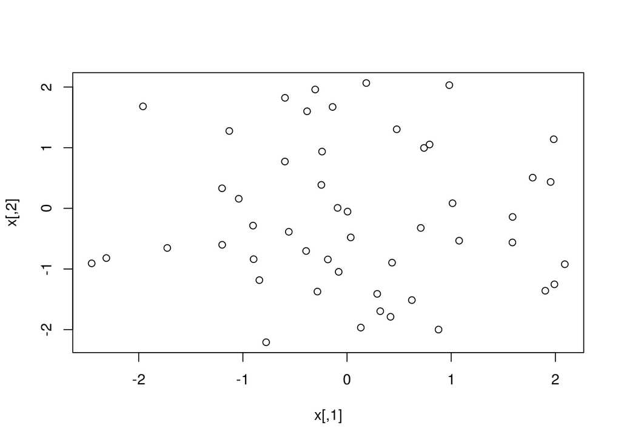

```r
set.seed(2)
x = matrix(rnorm(50*2),ncol = 2)
plot(x)
```

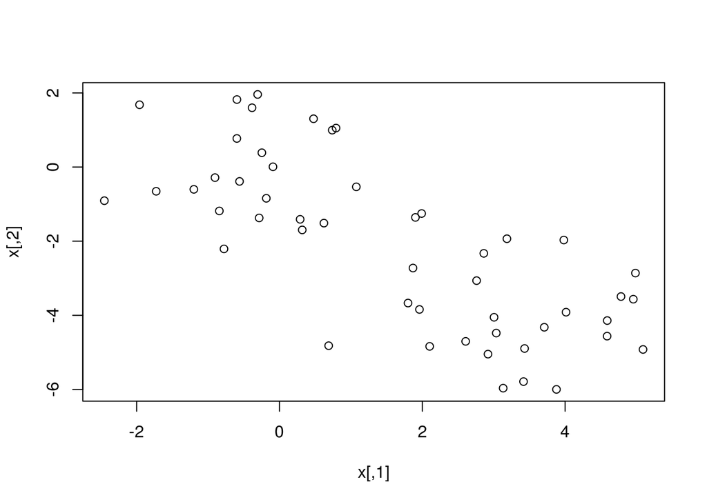

```r
x[1:25,1]=x[1:25,1]+3
x[1:25,2] = x[1:25,2]-4
plot(x)
```

```r
km.out=kmeans(x,2,nstart = 20)
km.out
```

```
## K-means clustering with 2 clusters of sizes 25, 25
##
## Cluster means:
##         [,1]       [,2]
## 1 -0.1956978 -0.1848774
## 2  3.3339737 -4.0761910
##
## Clustering vector:
##  [1] 2 2 2 2 2 2 2 2 2 2 2 2 2 2 2 2 2 2 2 2 2 2 2 2 2 1 1 1 1 1 1 1 1 1 1
## [36] 1 1 1 1 1 1 1 1 1 1 1 1 1 1 1
##
## Within cluster sum of squares by cluster:
## [1] 65.40068 63.20595
##  (between_SS / total_SS =  72.8 %)
##
## Available components:
##
## [1] "cluster"      "centers"      "totss"        "withinss"
## [5] "tot.withinss" "betweenss"    "size"         "iter"
## [9] "ifault"
```

```r
km.out$cluster
```

```
##  [1] 2 2 2 2 2 2 2 2 2 2 2 2 2 2 2 2 2 2 2 2 2 2 2 2 2 1 1 1 1 1 1 1 1 1 1
## [36] 1 1 1 1 1 1 1 1 1 1 1 1 1 1 1
```

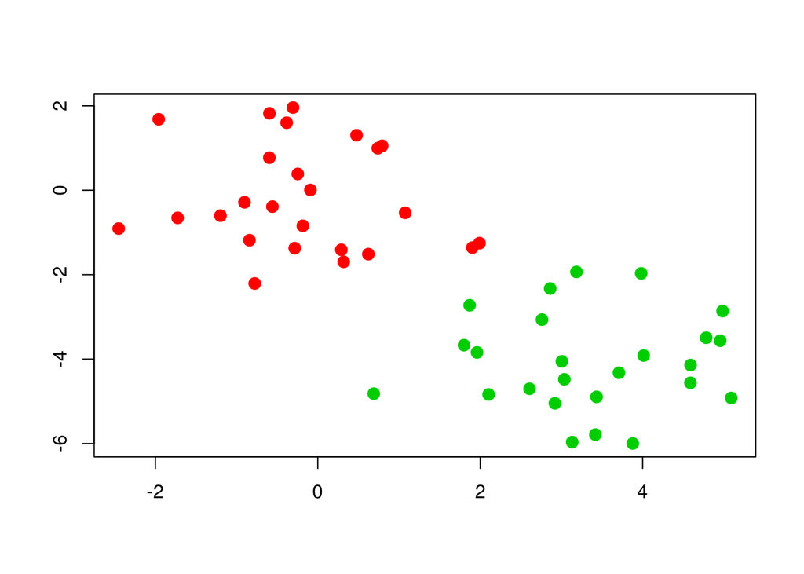

```r
plot(x,col=(km.out$cluster+1),mains="K-Means Clustering with k=2",xlab = "",ylab = "",pch=20,cex=2)
```

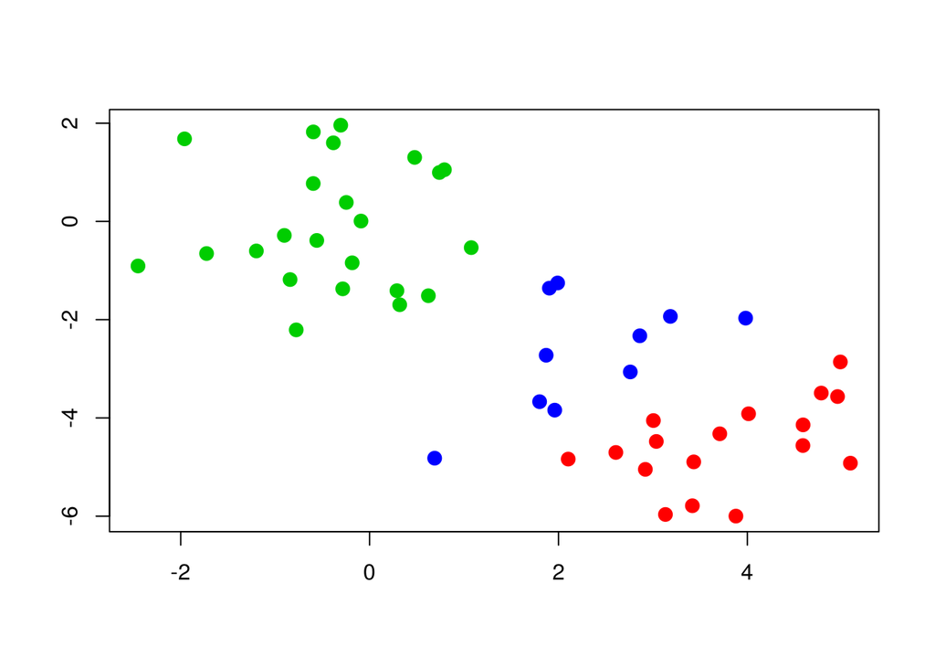

```r
km.out3 = kmeans(x,3,nstart = 20)
plot(x,col=(km.out3$cluster+1),mains="K-Means Clustering with k=2",xlab = "",ylab = "",pch=20,cex=2)
```

### Hierarchial clustering

Need not specify number of clusters beforehand, it builds a dendogram with all the observations at the bottem and fusing them hierarchially based on the choise of similarity and we can cut the dendogram at some height to get clusters in the observations.

Dendogram is built by height of the fusion from the bottom as the measure of dissimilarity and horizontal distance holding no significance.

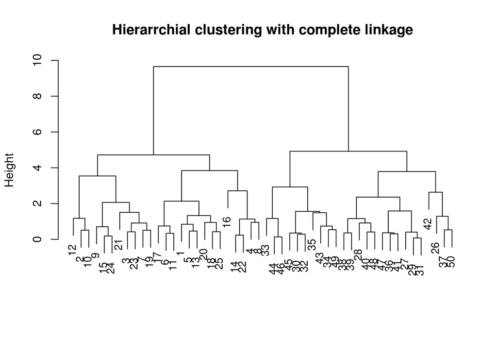

```r
hclust.complete = hclust(dist(x),method = "complete")
plot(hclust.complete,main = "Hierarrchial clustering with complete linkage",xlab = "",sub = "",cex=0.9)
```

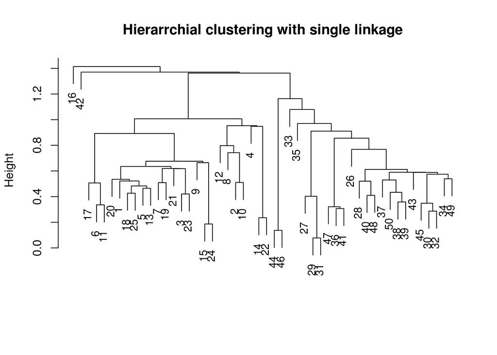

```r
hclust.single = hclust(dist(x),method = "single")
plot(hclust.single,main = "Hierarrchial clustering with single linkage",xlab = "",sub = "",cex=0.9)
```

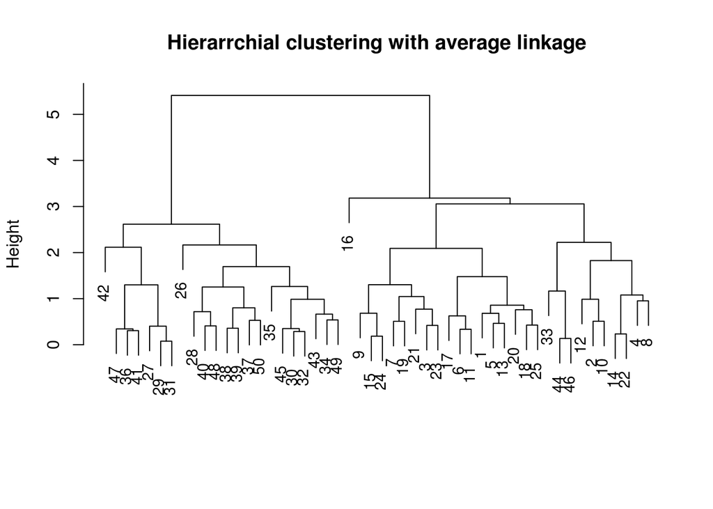

```r
hclust.average = hclust(dist(x),method = "average")
plot(hclust.average,main = "Hierarrchial clustering with average linkage",xlab = "",sub = "",cex=0.9)
```

single linkage results in a single observation for a cluster

```r
cutree(hclust.single,4)
```

```
##  [1] 1 1 1 1 1 1 1 1 1 1 1 1 1 1 1 2 1 1 1 1 1 1 1 1 1 3 3 3 3 3 3 3 3 3 3
## [36] 3 3 3 3 3 3 4 3 3 3 3 3 3 3 3
```

still two singletons with single linkage, average and complete linkage doesn’t suffer from these

```r
cutree(hclust.average,2)
```

```
##  [1] 1 1 1 1 1 1 1 1 1 1 1 1 1 1 1 1 1 1 1 1 1 1 1 1 1 2 2 2 2 2 2 2 1 2 2
## [36] 2 2 2 2 2 2 2 2 1 2 1 2 2 2 2
```

```r
cutree(hclust.complete,2)
```

```
##  [1] 1 1 1 1 1 1 1 1 1 1 1 1 1 1 1 1 1 1 1 1 1 1 1 1 1 2 2 2 2 2 2 2 2 2 2
## [36] 2 2 2 2 2 2 2 2 2 2 2 2 2 2 2
```

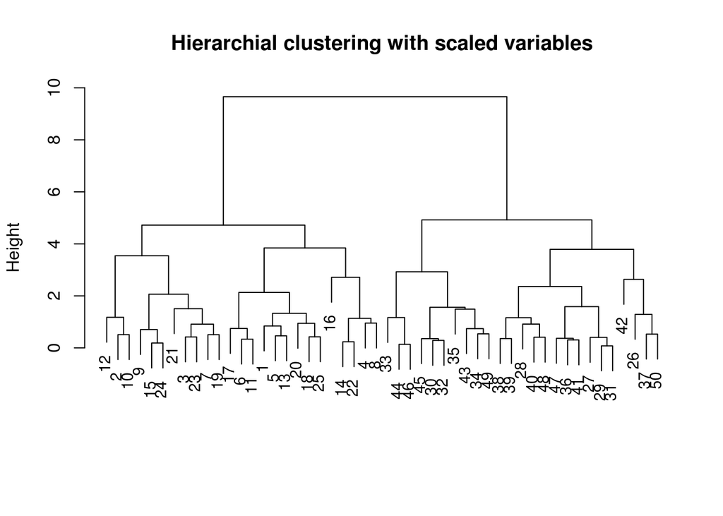

```r
xsc = scale(x)
hclust.scaled = hclust(dist(x),method="complete")
plot(hclust.scaled,main="Hierarchial clustering with scaled variables",xlab = "",sub = "",cex=0.9)
```

**Using correlation based distances**

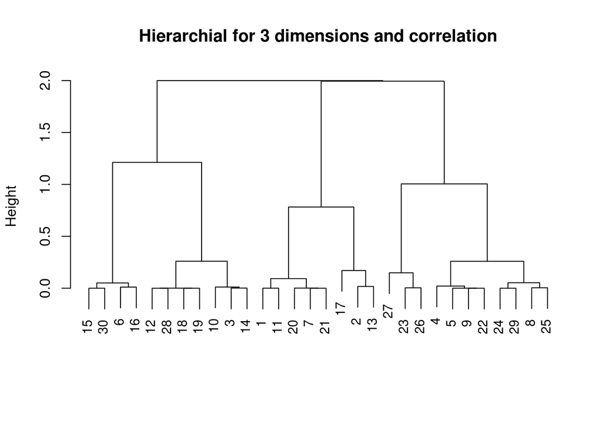

```r
x= matrix(rnorm(30*3),ncol = 3)
distMatrix = as.dist(1-cor(t(x)))
hclust.correlation = hclust(distMatrix,method = "complete")
plot(hclust.correlation,main="Hierarchial for 3 dimensions and correlation",xlab = "",sub = "",cex = 0.9)
```

```r
x=rep(1:4,25)
y=rep(1:2,50)
DataSet = cbind(x,y,rnorm(100,2,4),rpois(100,0.1))
library(dplyr)
library(ggplot2)
str(DataSet)
```

```
##  num [1:100, 1:4] 1 2 3 4 1 2 3 4 1 2 ...
##  - attr(*, "dimnames")=List of 2
##   ..$ : NULL
##   ..$ : chr [1:4] "x" "y" "" ""
```

```r
DataSet = as.data.frame(DataSet)
p=DataSet %>% group_by(x) %>%tally()
p
```

```
## # A tibble: 4 × 2
##       x     n
##   <dbl> <int>
## 1     1    25
## 2     2    25
## 3     3    25
## 4     4    25
```

```r
q=DataSet %>% group_by(y) %>% summarise(count = n())
q
```

```
## # A tibble: 2 × 2
##       y count
##   <dbl> <int>
## 1     1    50
## 2     2    50
```

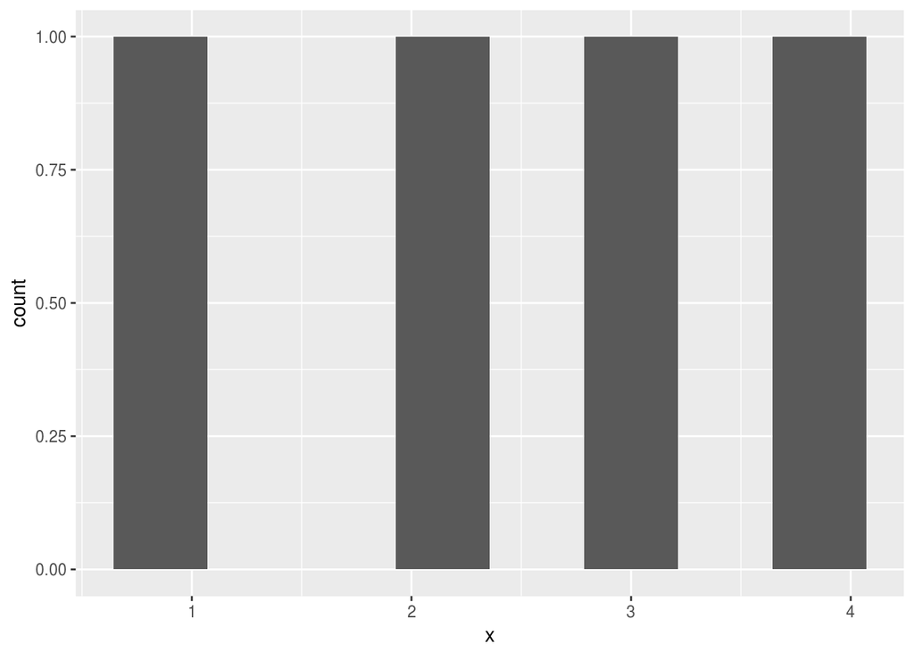

```r
ggplot(p,aes(x))+geom_histogram(bins = 8)
```

### Practical issues in clustering

1. For clustering using any method it needs a choice of dissimilarity and decision on centering and scaling of the features, additionally K-Means requires number of clusters beforehand and hierarchial needs type of linkage and height at which dendogram is cut.
2. whether the clusters are valid or are they a result of clustering noise?
3. Both algorithms assign each observation into clusters, what if even though most of the observations belong to small number of subgroups and a small group is different from each other and all other groups? forcing each observations into clusters might make the clusters heavily distorted due to outliers, not very robust to pertubation of data( different clusters in a subset)

## NC160 Data Example

NCI60 cancer cell line microarray data,consists of 6830 gene expression measurements on 64 cancer cell lines. Data is from *‘ISLR’* package, each cell line is labelled with cancer type which is removed while performing clustering and used for checking the results

```r
library(ISLR)
str(NCI60)
```

```
## List of 2
##  $ data: num [1:64, 1:6830] 0.3 0.68 0.94 0.28 0.485 ...
##   ..- attr(*, "dimnames")=List of 2
##   .. ..$ : chr [1:64] "V1" "V2" "V3" "V4" ...
##   .. ..$ : chr [1:6830] "1" "2" "3" "4" ...
##  $ labs: chr [1:64] "CNS" "CNS" "CNS" "RENAL" ...
```

```r
str(NCI60$data)
```

```
##  num [1:64, 1:6830] 0.3 0.68 0.94 0.28 0.485 ...
##  - attr(*, "dimnames")=List of 2
##   ..$ : chr [1:64] "V1" "V2" "V3" "V4" ...
##   ..$ : chr [1:6830] "1" "2" "3" "4" ...
```

```r
rownames(NCI60$data)
```

```
##  [1] "V1"  "V2"  "V3"  "V4"  "V5"  "V6"  "V7"  "V8"  "V9"  "V10" "V11"
## [12] "V12" "V13" "V14" "V15" "V16" "V17" "V18" "V19" "V20" "V21" "V22"
## [23] "V23" "V24" "V25" "V26" "V27" "V28" "V29" "V30" "V31" "V32" "V33"
## [34] "V34" "V35" "V36" "V37" "V38" "V39" "V40" "V41" "V42" "V43" "V44"
## [45] "V45" "V46" "V47" "V48" "V49" "V50" "V51" "V52" "V53" "V54" "V55"
## [56] "V56" "V57" "V58" "V59" "V60" "V61" "V62" "V63" "V64"
```

```r
# using data for unsupervised learning and labs for verification of results
ncdata = tbl_df(NCI60$data)
NCI60$labs %>% table()
```

```
## .
##      BREAST         CNS       COLON K562A-repro K562B-repro    LEUKEMIA
##           7           5           7           1           1           6
## MCF7A-repro MCF7D-repro    MELANOMA       NSCLC     OVARIAN    PROSTATE
##           1           1           8           9           6           2
##       RENAL     UNKNOWN
##           9           1
```

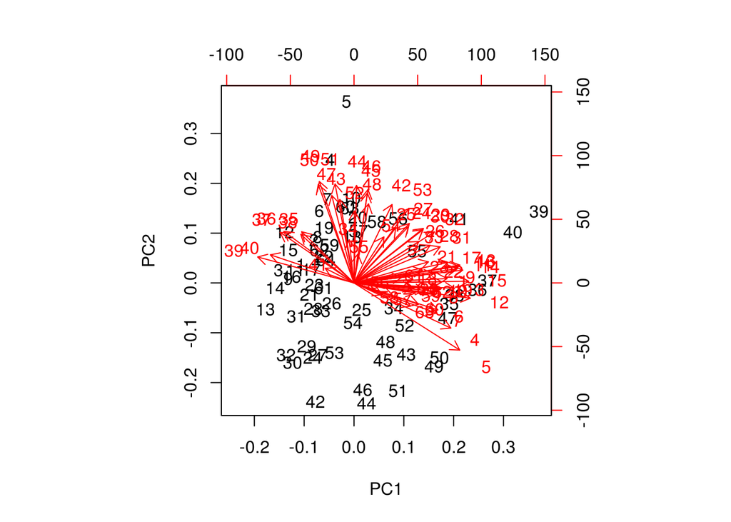

```r
nci.labs = NCI60$labs
#names(ncdata)
#PCA
prncdata = prcomp(dist(ncdata))
prncdata.scaled = prcomp(dist(ncdata),scale. = T)
biplot(prncdata)
```

```r
Cols = function(vec) {
        cols = rainbow(length(unique(vec)))
        return(cols[as.numeric(as.factor(vec))])
}
prncdata
```

[output not shown]

[output cut: 846 more lines]

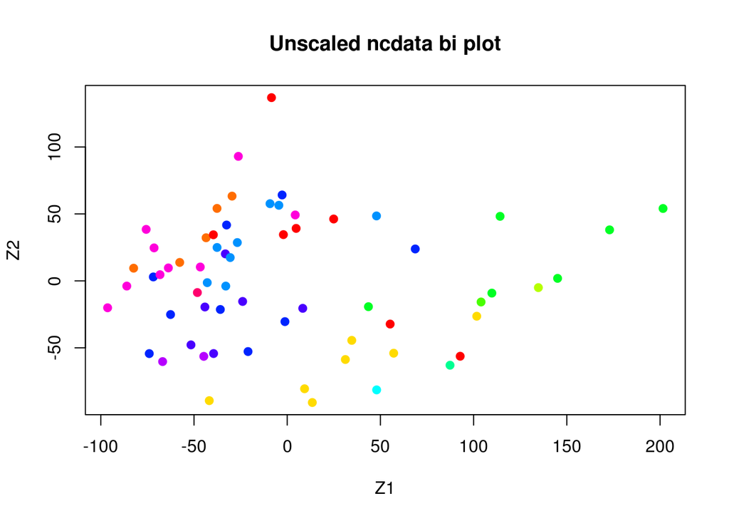

```r
prncdata.summary = summary(prncdata)
prncdata.scaled.summary = summary(prncdata.scaled)
plot(prncdata$x[,1:2],col=Cols(nci.labs),pch=19,xlab = "Z1",ylab = "Z2",main="Unscaled ncdata bi plot")
```

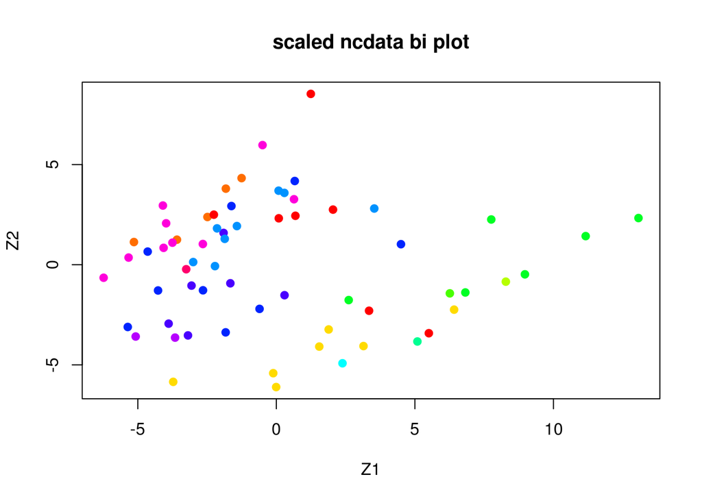

```r
plot(prncdata.scaled$x[,1:2],col=Cols(nci.labs),pch=19,xlab = "Z1",ylab = "Z2",main="scaled ncdata bi plot")
```

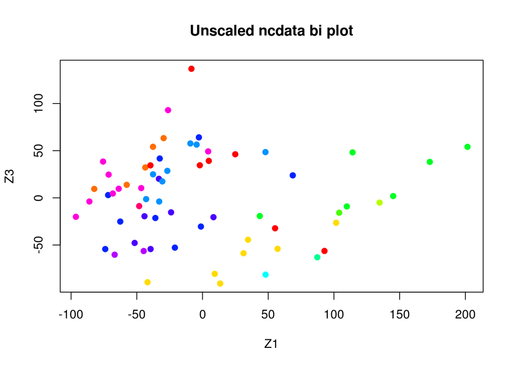

```r
plot(prncdata$x[,1:3],col=Cols(nci.labs),pch=19,xlab = "Z1",ylab = "Z3",main="Unscaled ncdata bi plot")
```

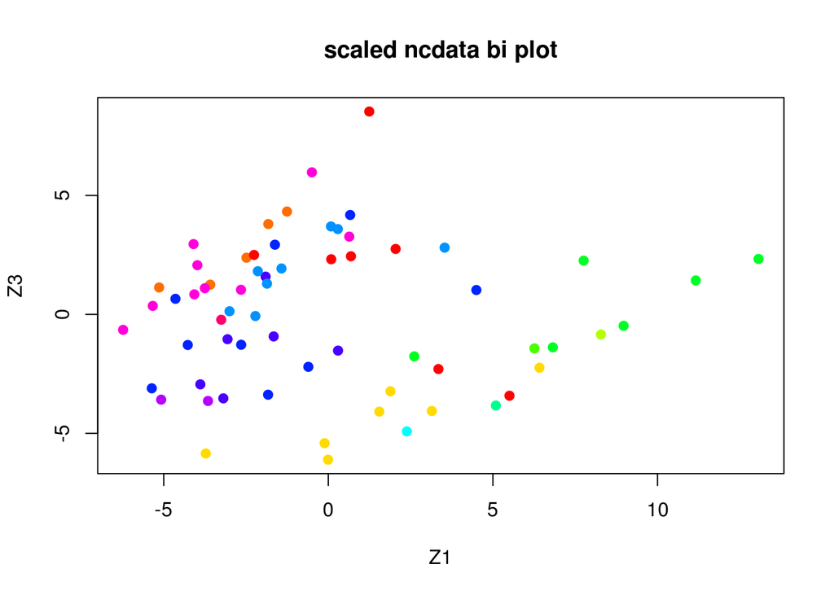

```r
plot(prncdata.scaled$x[,1:3],col=Cols(nci.labs),pch=19,xlab = "Z1",ylab = "Z3",main="scaled ncdata bi plot")
```

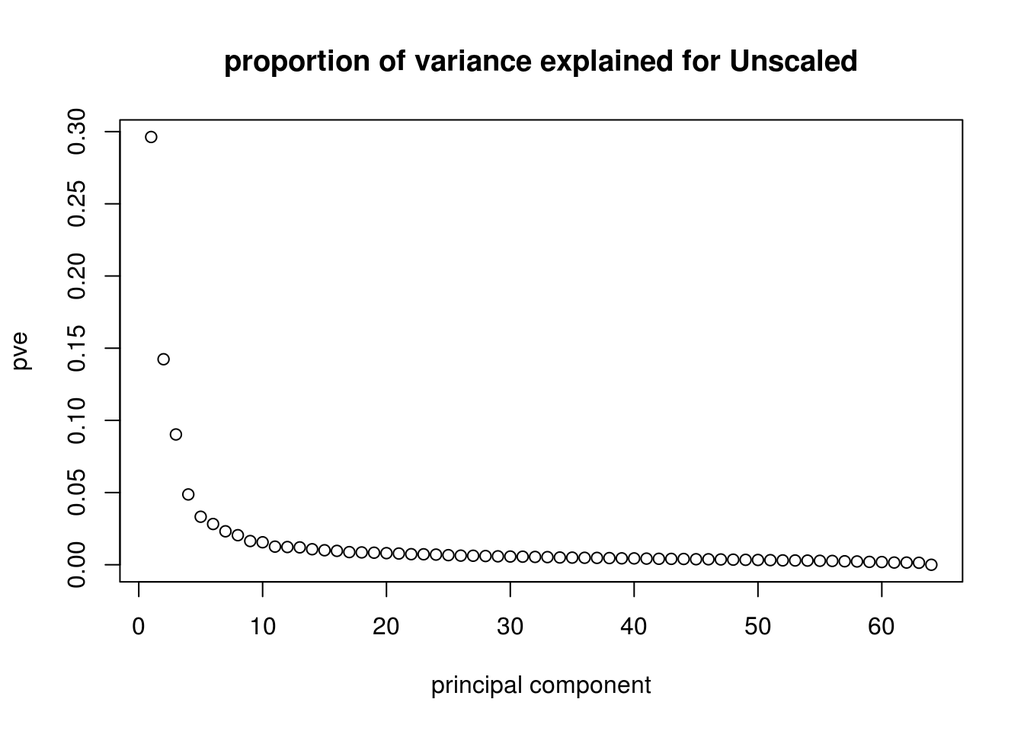

```r
plot(prncdata.summary$importance[2,],main="proportion of variance explained for Unscaled",xlab = "principal component",ylab = "pve")
```

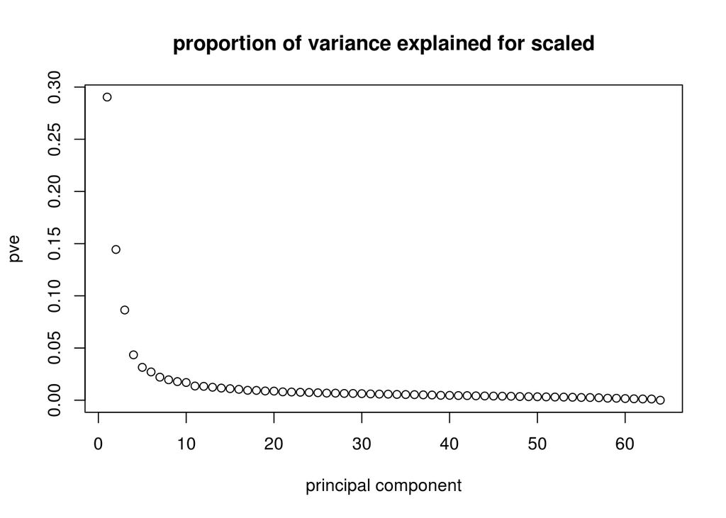

```r
plot(prncdata.scaled.summary$importance[2,],main="proportion of variance explained for scaled",xlab = "principal component",ylab = "pve")
```

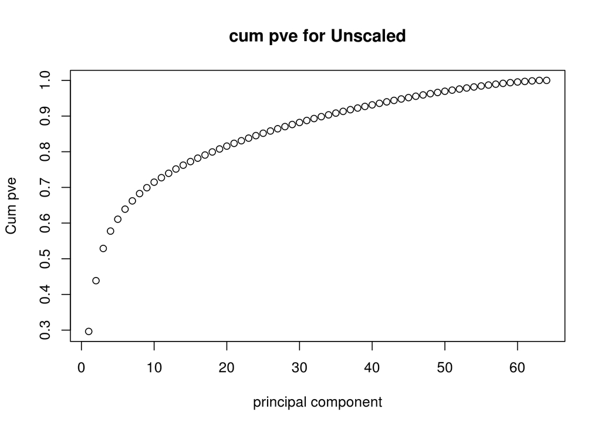

```r
plot(prncdata.summary$importance[3,],main="cum pve for Unscaled",xlab = "principal component",ylab = "Cum pve")
```

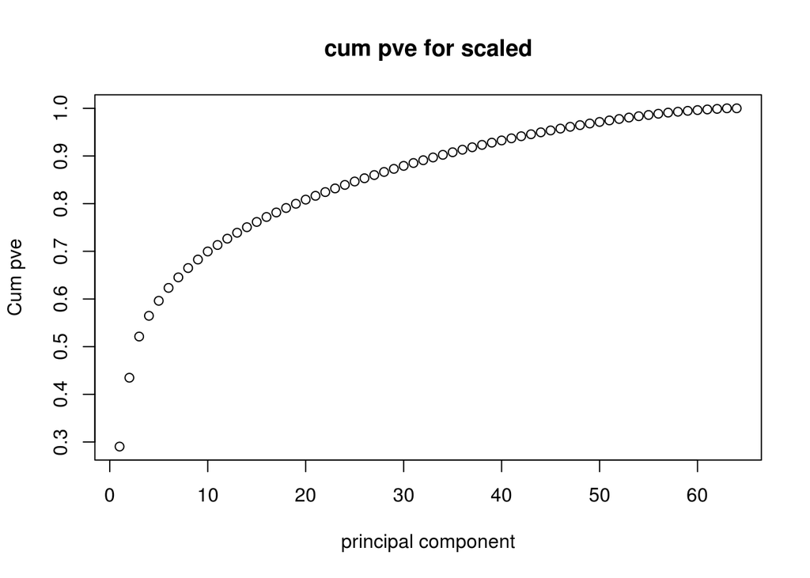

```r
plot(prncdata.scaled.summary$importance[3,],main="cum pve for scaled",xlab = "principal component",ylab = "Cum pve")
```

Practical dificulties faced while doing pca on nci60 data 1. should we scale the variance Did PCA for both the cases as it is not clear whether to scale gene expressions(Every column is gene expression so scaling may reduce the weight for expression by gene(or cell) with high variance. 2. How many components to use. As expected the scree plot have elbow at 5 pCA with 61% variance applied but at 10 its at 71% and at 20 81%, so 7 or 8 may be a good choice with 66% and 68% of variance explained

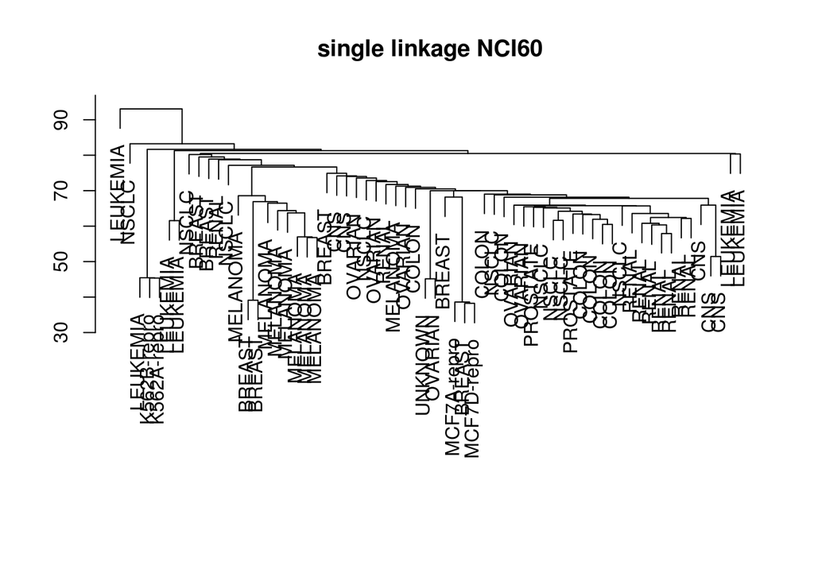

```r
sd.data = scale(ncdata)
data.dist = dist(ncdata)
ncd.hclust.complete = hclust(data.dist,method = "complete")
ncd.hclust.average = hclust(data.dist,method = "complete")
ncd.hclust.single = hclust(data.dist,method = "single")
plot(ncd.hclust.single,main = "single linkage NCI60" ,labels=nci.labs,xlab = "",ylab = "",sub = "")
```